# Hedonic Regression - Rosen’s Two Steps

Lucas Salamuni

2025-12-23

# 1. Packages

## 1.1. Retrieving Packages

```r
pacotes <- c("tidyverse", "factoextra", "readxl", "ggplot2", "writexl", "spdep",
             "cowplot", "car", "lmtest", "psych", "car", "tseries", "MASS",
             "whitestrap", "jtools", "sandwich", "foreign", "plm", "lm.beta",
             "conleyreg", "sf")

if(sum(as.numeric(!pacotes %in% installed.packages())) != 0){
  instalador <- pacotes[!pacotes %in% installed.packages()]
  for(i in 1:length(instalador)) {
    install.packages(instalador, dependencies = T)
    break()}
  sapply(pacotes, require, character = T)
} else {
  sapply(pacotes, require, character = T)
}
```

```
##  tidyverse factoextra     readxl    ggplot2    writexl      spdep    cowplot
##       TRUE       TRUE       TRUE       TRUE       TRUE       TRUE       TRUE
##        car     lmtest      psych        car    tseries       MASS whitestrap
##       TRUE       TRUE       TRUE       TRUE       TRUE       TRUE       TRUE
##     jtools   sandwich    foreign        plm    lm.beta  conleyreg         sf
##       TRUE       TRUE       TRUE       TRUE       TRUE       TRUE       TRUE
```

# 2. Exploratory Analysis

## 2.1. Accessing the Data

```r
low_tier <- read_excel("C:/Users/Lucas/OneDrive/Lucas Salamuni/Universidades/Universitat zu Koln/Semester 3/RG Econometrics/Proposal/Datasets/Low_tier.xlsx")

mid_tier <- read_excel("C:/Users/Lucas/OneDrive/Lucas Salamuni/Universidades/Universitat zu Koln/Semester 3/RG Econometrics/Proposal/Datasets/Medium_tier.xlsx")

high_tier <- read_excel("C:/Users/Lucas/OneDrive/Lucas Salamuni/Universidades/Universitat zu Koln/Semester 3/RG Econometrics/Proposal/Datasets/High_tier.xlsx")
```

## 2.2. Dividing into low, mid and high tiers

```r
tibble("Low" = as.numeric(count(low_tier)),
       "Mid" = as.numeric(count(mid_tier)),
       "High" = as.numeric(count(high_tier)),
       "TOTAL" = as.numeric(count(low_tier)) + as.numeric(count(mid_tier)) + as.numeric(count(high_tier)))
```

| Low | Mid | High | TOTAL |
| --- | --- | --- | --- |
| 1043 | 2126 | 1125 | 4294 |

## 2.3. Checking price trends using a linear function form

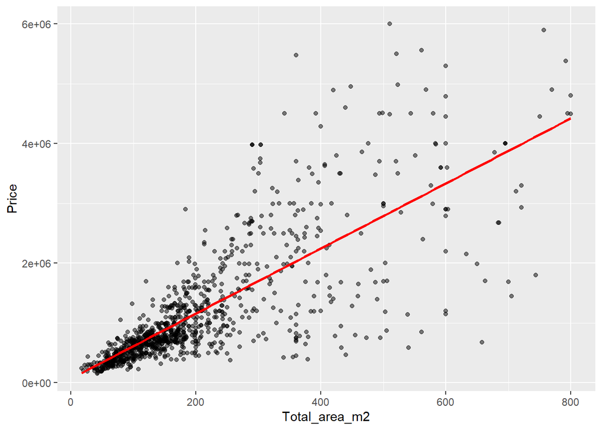

```r
low_tier %>%
  ggplot(aes(x = Total_area_m2,
             y = Price)) +
  geom_point(alpha = 0.5) +
  geom_smooth(method = "lm",
              se = FALSE,
              color = "red")
```

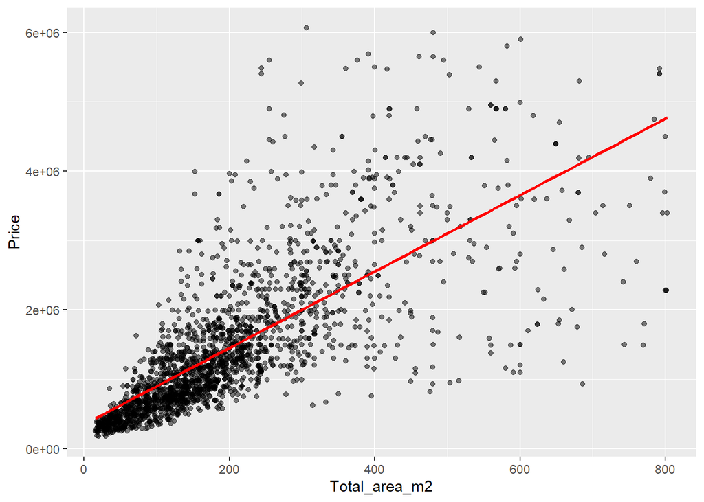

```r
mid_tier %>%
  ggplot(aes(x = Total_area_m2,
             y = Price)) +
  geom_point(alpha = 0.5) +
  geom_smooth(method = "lm",
              se = FALSE,
              color = "red")
```

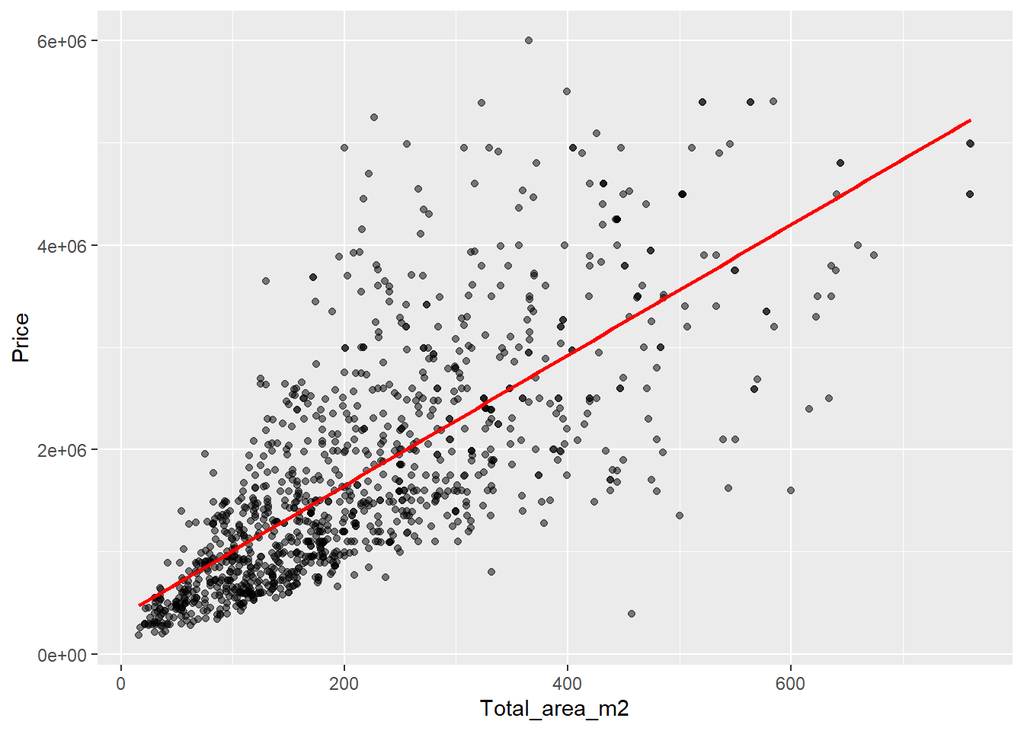

```r
high_tier %>%
  ggplot(aes(x = Total_area_m2,
             y = Price)) +
  geom_point(alpha = 0.5) +
  geom_smooth(method = "lm",
              se = FALSE,
              color = "red")
```

- NOTE 1 = Linear models assume that Y exhibits constant absolute increases (or decreases) given absolute variations in X. Thus, the marginal change in the expected value of Y is the same for any value of X.

## 2.4. Checking price trends using a semi-logarithmic function form

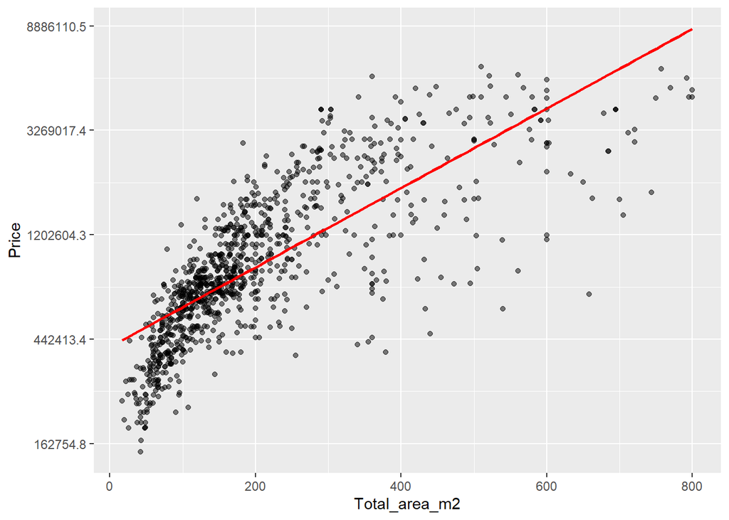

```r
low_tier %>%
  ggplot(aes(x = Total_area_m2,
             y = Price)) +
  geom_point(alpha = 0.5) +
  scale_y_continuous(trans = "log") +
  geom_smooth(method = "lm",
              se = FALSE,
              color = "red")
```

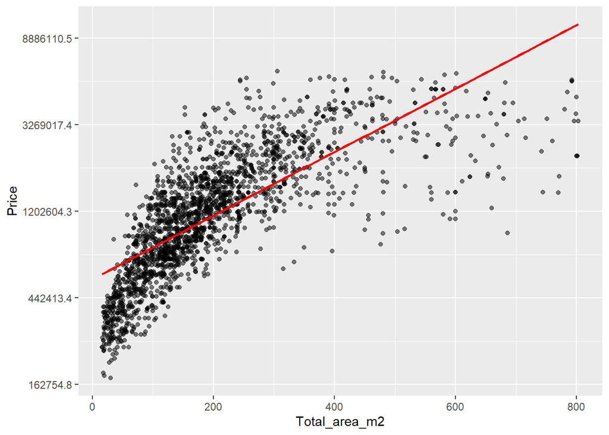

```r
mid_tier %>%
  ggplot(aes(x = Total_area_m2,
             y = Price)) +
  geom_point(alpha = 0.5) +
  scale_y_continuous(trans = "log") +
  geom_smooth(method = "lm",
              se = FALSE,
              color = "red")
```

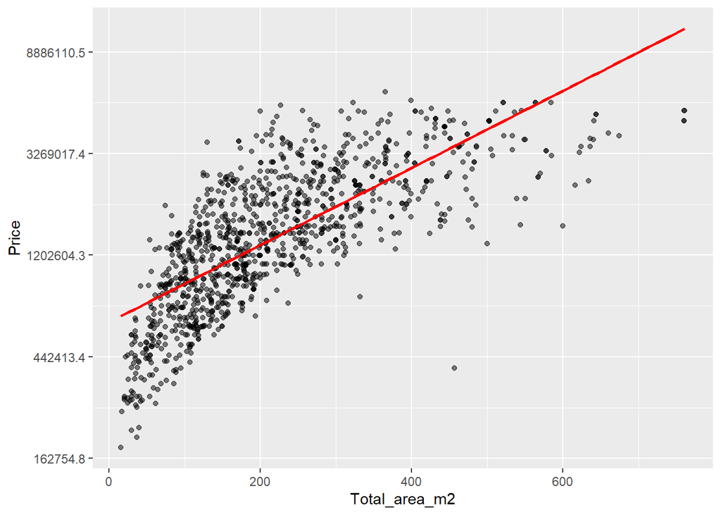

```r
high_tier %>%
  ggplot(aes(x = Total_area_m2,
             y = Price)) +
  geom_point(alpha = 0.5) +
  scale_y_continuous(trans = "log") +
  geom_smooth(method = "lm",
              se = FALSE,
              color = "red")
```

- NOTE 2 = Semi-logarithmic (or log-linear) models assume that Y exhibits exponential growth (or decay) in relation to absolute variations in X.

## 2.5. Checking price trends using a double logarithmic function form

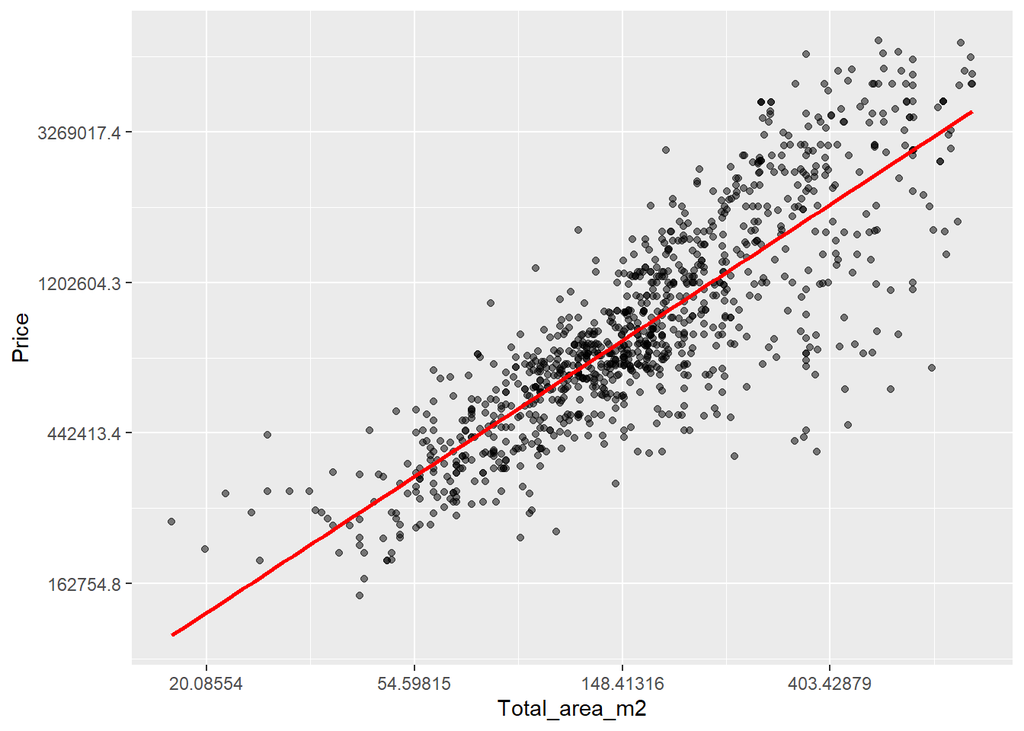

```r
low_tier %>%
  ggplot(aes(x = Total_area_m2,
             y = Price)) +
  geom_point(alpha = 0.5) +
  scale_x_continuous(trans = "log") +
  scale_y_continuous(trans = "log") +
  geom_smooth(method = "lm",
              se = FALSE,
              color = "red")
```

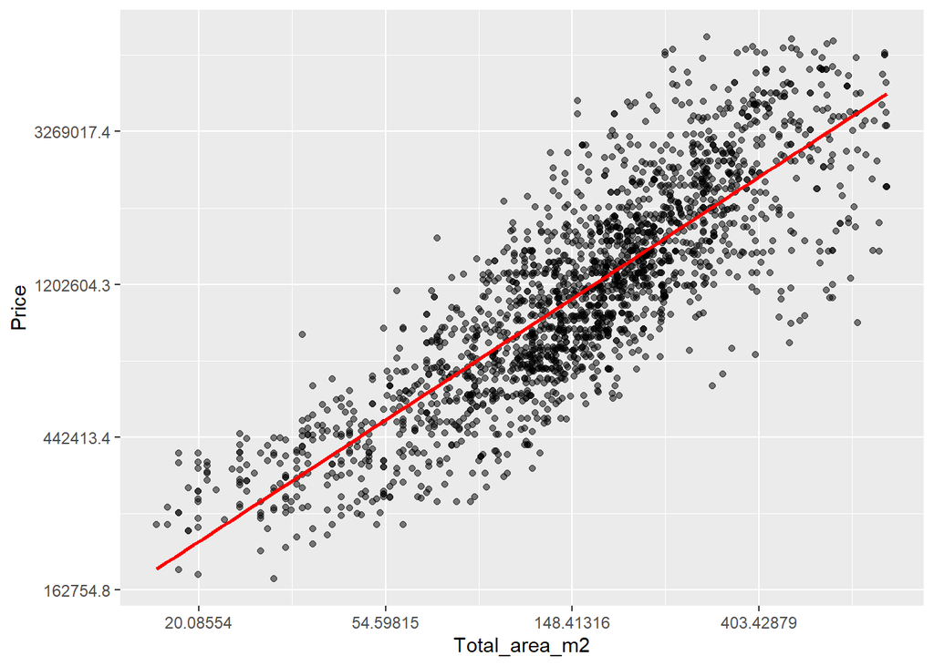

```r
mid_tier %>%
  ggplot(aes(x = Total_area_m2,
             y = Price)) +
  geom_point(alpha = 0.5) +
  scale_x_continuous(trans = "log") +
  scale_y_continuous(trans = "log") +
  geom_smooth(method = "lm",
              se = FALSE,
              color = "red")
```

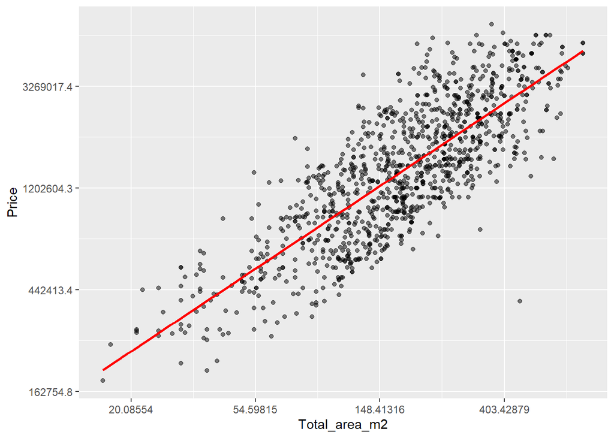

```r
high_tier %>%
  ggplot(aes(x = Total_area_m2,
             y = Price)) +
  geom_point(alpha = 0.5) +
  scale_x_continuous(trans = "log") +
  scale_y_continuous(trans = "log") +
  geom_smooth(method = "lm",
              se = FALSE,
              color = "red")
```

- NOTE 3 = Logarithmic (or double logarithmic) models assume that Y exhibits constant relative variations given relative variations in X. Thus, the beta coefficient would be a constant measure of the elasticity of Y in relation to X, meaning that it considers that relative variations in X are the same for any values of Xi and Yi.
- NOTE 4 = It seems that the functional form that best fits the model, across all tiers, is indeed the logarithmic form (log-log). In other words, the price of properties in its natural logarithmic form (lnY) is a function of the logarithms of the intrinsic characteristics of the property (I) and the urban amenities of its respective locality/neighborhood (A).

# 3. Box-Cox transformation to select functional-form

## 3.1. Low tier

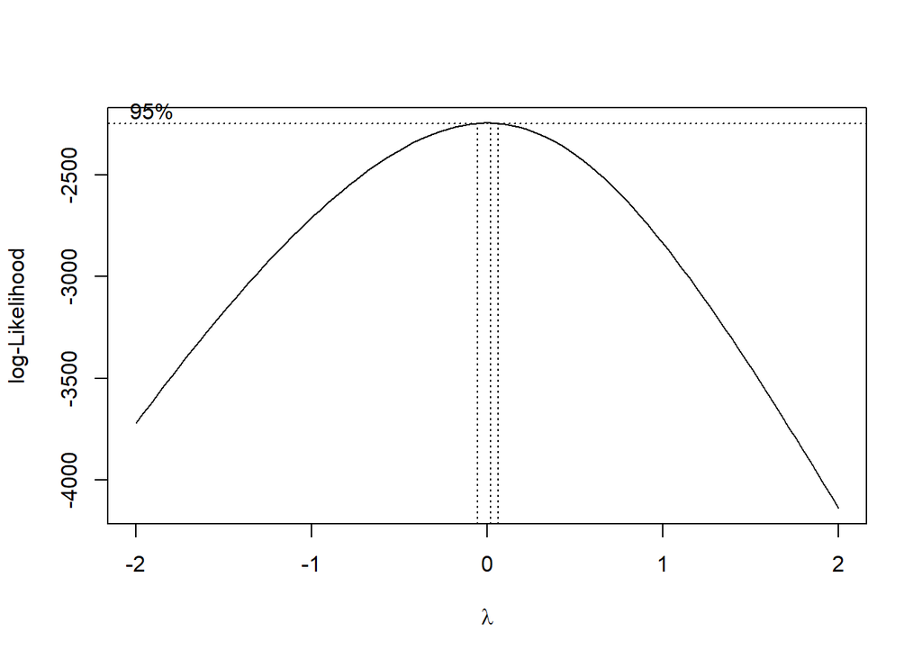

```r
model_intrinsic <- lm(data = low_tier,
                      Price ~ Total_area_m2 + Usable_area_m2 + Age_years + Apartment + Off_plan + Party_room +
                      Game_room + Gym + Pool + Sauna + BBQ + Gourmet_space + Sports_court + Guardhouse + Cameras +
                      Balcony + Playground + PARKING1 + PARKING2 + BEDROOM1 + BEDROOM2 + BEDROOM3 + BEDROOM4 +
                      BATHROOM1 + BATHROOM2 + BATHROOM3 + BATHROOM4)


bc <- boxcox(model_intrinsic, lambda = seq(-2,2, by = 0.1))
```

```r
bc$x[which.max(bc$y)]
```

```
## [1] 0.02020202
```

## 3.2. Mid tier

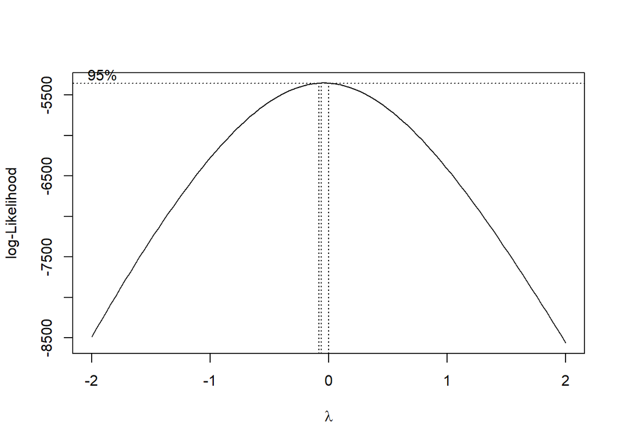

```r
model_intrinsic <- lm(data = mid_tier,
                      Price ~ Total_area_m2 + Usable_area_m2 + Age_years + Apartment + Off_plan + Party_room +
                      Game_room + Gym + Pool + Sauna + BBQ + Gourmet_space + Sports_court + Guardhouse + Cameras +
                      Balcony + Playground + PARKING1 + PARKING2 + BEDROOM1 + BEDROOM2 + BEDROOM3 + BEDROOM4 +
                      BATHROOM1 + BATHROOM2 + BATHROOM3 + BATHROOM4)


bc <- boxcox(model_intrinsic, lambda = seq(-2,2, by = 0.1))
```

```r
bc$x[which.max(bc$y)]
```

```
## [1] -0.06060606
```

## 3.3. High tier

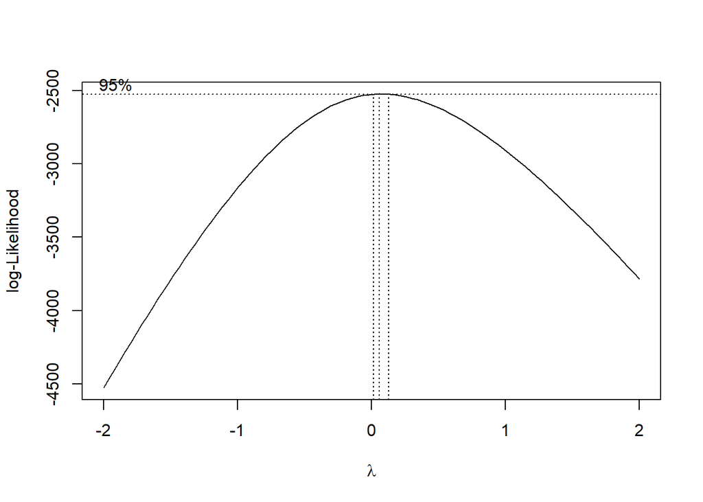

```r
model_intrinsic <- lm(data = high_tier,
                      Price ~ Total_area_m2 + Usable_area_m2 + Age_years + Apartment + Off_plan + Party_room +
                      Game_room + Gym + Pool + Sauna + BBQ + Gourmet_space + Sports_court + Guardhouse + Cameras +
                      Balcony + Playground + PARKING1 + PARKING2 + BEDROOM1 + BEDROOM2 + BEDROOM3 + BEDROOM4 +
                      BATHROOM1 + BATHROOM2 + BATHROOM3 + BATHROOM4)


bc <- boxcox(model_intrinsic, lambda = seq(-2,2, by = 0.1))
```

```r
bc$x[which.max(bc$y)]
```

```
## [1] 0.06060606
```

# 4. Rosen’s First Stage

## 4.1. Low tier

### 4.1.1. First Regression (First Stage of Rosen - Only Intrinsic Characteristics)

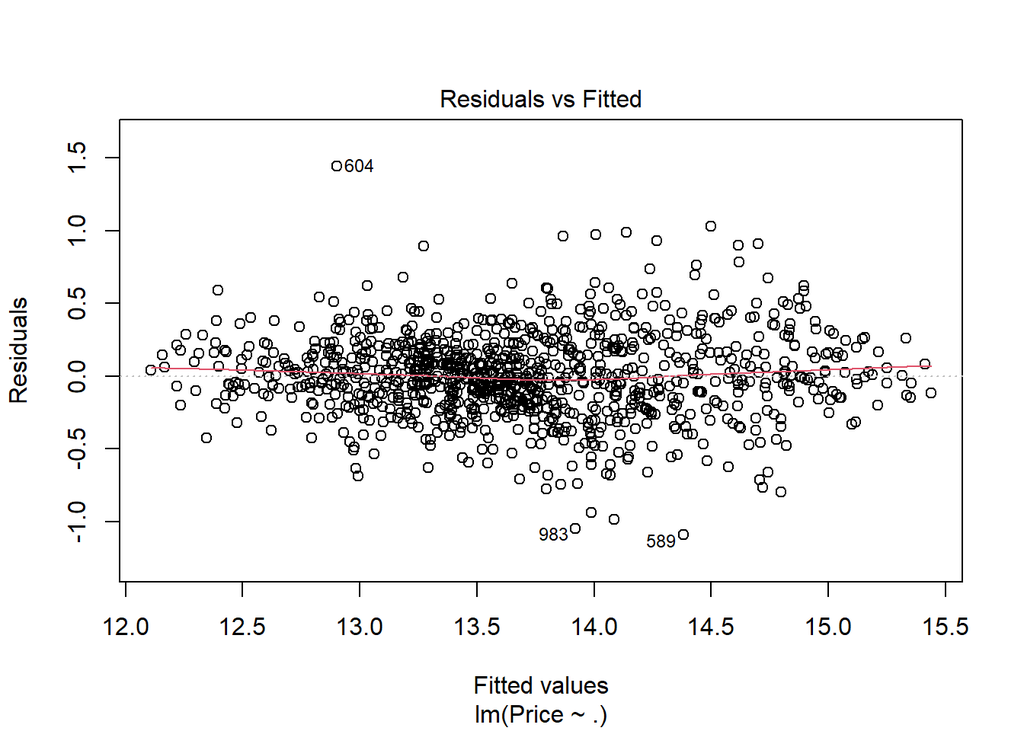

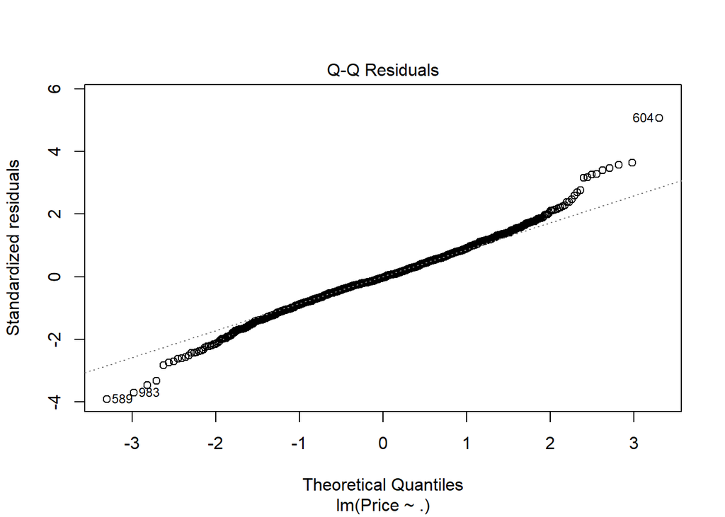

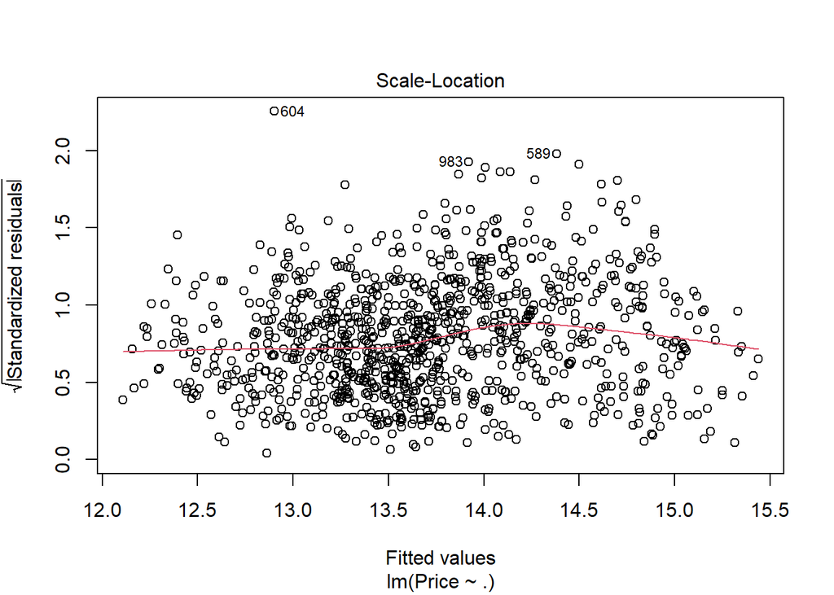

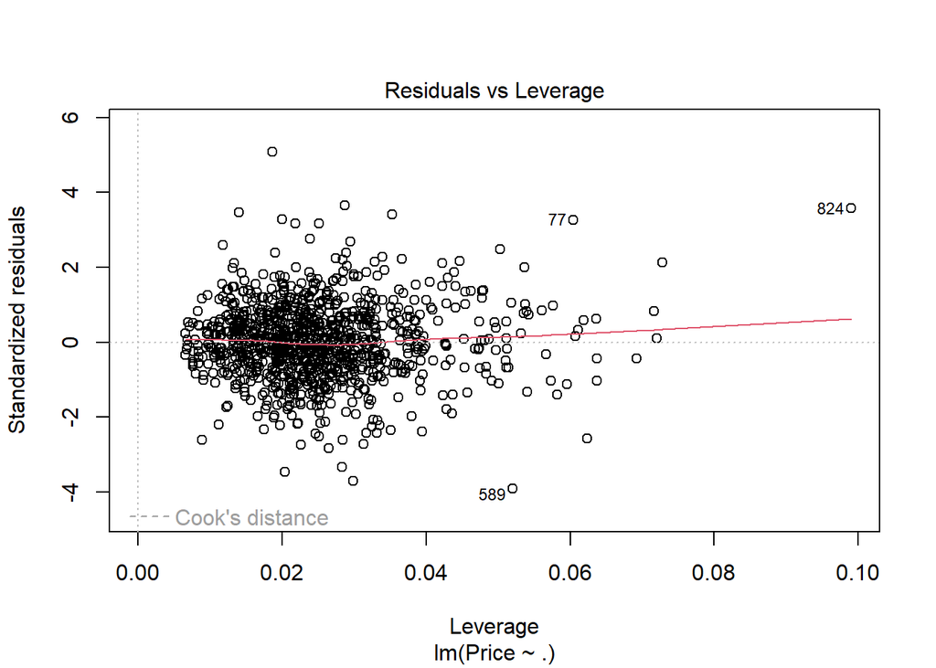

```r
low_tier_ln <- low_tier %>%
  mutate_at(vars(Price, Total_area_m2), log) %>%
  mutate(Age_years = log(Age_years + 1)) %>%
  mutate_at(vars(Price, Total_area_m2),
            ~ifelse(is.infinite(.), 0, .)) %>%
  dplyr::select(-c(NEIGHBORHOOD, Apartment, Usable_area_m2, POPULATION, DENSITY, CICLOWAYS,
                   GREEN_AREA, HOSPITALS, TERMINALS, PRIVATE_SCHOOLS, PUBLIC_SCHOOLS,
                   CULTURE_FACILITIES, SHOPPINGS, latitude, longitude, full_address))

low_lm_ln <- lm(Price ~ .,
                data = low_tier_ln)

## Plots

plot(low_lm_ln)
```

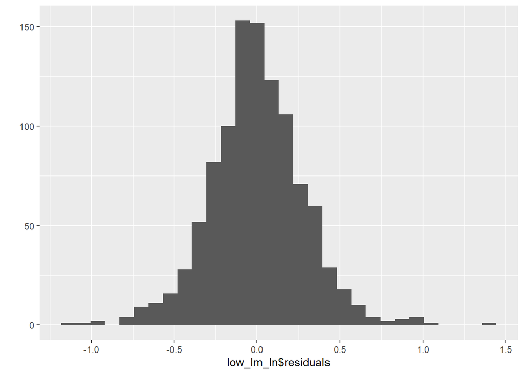

```r
qplot(low_lm_ln$residuals)
```

```r
## Normality

jarque.bera.test(low_lm_ln$residuals)
```

```
##
##  Jarque Bera Test
##
## data:  low_lm_ln$residuals
## X-squared = 110.55, df = 2, p-value < 2.2e-16
```

```r
## Heteroskedasticity

white_test(low_lm_ln)
```

```
## White's test results
##
## Null hypothesis: Homoskedasticity of the residuals
## Alternative hypothesis: Heteroskedasticity of the residuals
## Test Statistic: 21.82
## P-value: 1.8e-05
```

```r
## Spatial autocorrelation

low_tier_sf <- low_tier %>%
  filter(!is.na(latitude) & !is.na(longitude)) %>%
  st_as_sf(coords = c("longitude", "latitude"), crs = 4326)

coords <- st_coordinates(low_tier_sf)
knn <- knearneigh(coords, k = 5)
nb <- knn2nb(knn)
listw <- nb2listw(nb, style = "W")

residuals_low <- residuals(low_lm_ln)

moran.test(residuals_low, listw)
```

```
##
##  Moran I test under randomisation
##
## data:  residuals_low
## weights: listw
##
## Moran I statistic standard deviate = 9.8022, p-value < 2.2e-16
## alternative hypothesis: greater
## sample estimates:
## Moran I statistic       Expectation          Variance
##      0.1758882190     -0.0009596929      0.0003255037
```

```r
## Multicolinearity

car::vif(low_lm_ln)
```

```
##      Off_plan Total_area_m2     Age_years    Party_room     Game_room
##      1.518887      3.376492      1.798150      2.101909      1.790701
##           Gym          Pool         Sauna           BBQ Gourmet_space
##      1.876179      1.639122      1.243316      1.241961      1.384107
##  Sports_court    Guardhouse       Cameras       Balcony    Playground
##      1.789393      1.555588      1.191438      1.184677      2.427660
##      PARKING1      PARKING2      BEDROOM1      BEDROOM2      BEDROOM3
##      2.414637      3.299442      7.041339     13.601669      9.868750
##      BEDROOM4     BATHROOM1     BATHROOM2     BATHROOM3     BATHROOM4
##      2.966913      2.442589      3.685062      3.352547      3.680055
```

```r
## Summary

summary(low_lm_ln)
```

```
##
## Call:
## lm(formula = Price ~ ., data = low_tier_ln)
##
## Residuals:
##      Min       1Q   Median       3Q      Max
## -1.09398 -0.16469 -0.00766  0.16470  1.44276
##
## Coefficients:
##                Estimate Std. Error t value Pr(>|t|)
## (Intercept)   10.287097   0.111757  92.049  < 2e-16 ***
## Off_plan      -0.103876   0.038396  -2.705 0.006937 **
## Total_area_m2  0.611501   0.024516  24.943  < 2e-16 ***
## Age_years     -0.106769   0.010610 -10.063  < 2e-16 ***
## Party_room     0.134539   0.026115   5.152 3.10e-07 ***
## Game_room     -0.058928   0.030657  -1.922 0.054861 .
## Gym            0.099757   0.026512   3.763 0.000178 ***
## Pool           0.133327   0.025983   5.131 3.45e-07 ***
## Sauna          0.063141   0.038804   1.627 0.104007
## BBQ            0.050878   0.023178   2.195 0.028382 *
## Gourmet_space  0.067723   0.021043   3.218 0.001330 **
## Sports_court  -0.034672   0.025357  -1.367 0.171817
## Guardhouse    -0.040032   0.023930  -1.673 0.094655 .
## Cameras       -0.027661   0.026824  -1.031 0.302689
## Balcony        0.002144   0.020138   0.106 0.915222
## Playground     0.096544   0.028335   3.407 0.000682 ***
## PARKING1       0.054367   0.028142   1.932 0.053651 .
## PARKING2       0.148976   0.034406   4.330 1.64e-05 ***
## BEDROOM1      -0.069250   0.063636  -1.088 0.276754
## BEDROOM2       0.052270   0.066899   0.781 0.434797
## BEDROOM3       0.081639   0.073018   1.118 0.263802
## BEDROOM4       0.096901   0.087370   1.109 0.267657
## BATHROOM1      0.073395   0.032825   2.236 0.025572 *
## BATHROOM2      0.186316   0.037766   4.933 9.44e-07 ***
## BATHROOM3      0.346995   0.042118   8.239 5.32e-16 ***
## BATHROOM4      0.543940   0.049519  10.985  < 2e-16 ***
## ---
## Signif. codes:  0 '***' 0.001 '**' 0.01 '*' 0.05 '.' 0.1 ' ' 1
##
## Residual standard error: 0.2867 on 1017 degrees of freedom
## Multiple R-squared:  0.8453, Adjusted R-squared:  0.8415
## F-statistic: 222.3 on 25 and 1017 DF,  p-value: < 2.2e-16
```

### 4.1.2. Addressing the spatial correlation and heteroscedasticity through Conley SEs

```r
low_tier_conley <- low_tier %>%
  filter(!is.na(latitude) & !is.na(longitude)) %>%
  mutate(Price = log(Price),
         Total_area_m2 = log(Total_area_m2),
         Age_years = log(Age_years + 1))

low_conley <- conleyreg(Price ~ Total_area_m2 + Age_years +
                          Off_plan + Party_room + Game_room + Gym + Pool +
                          Sauna + BBQ + Gourmet_space + Sports_court + Guardhouse +
                          Cameras + Balcony + Playground +
                          PARKING1 + PARKING2 +
                          BEDROOM1 + BEDROOM2 + BEDROOM3 + BEDROOM4 +
                          BATHROOM1 + BATHROOM2 + BATHROOM3 + BATHROOM4,
                        data = low_tier_conley,
                        lat = "latitude",
                        lon = "longitude",
                        dist_cutoff = 2)
```

```
## Checking spatial attributes
```

```
## Estimating model
```

```
## Estimating distance matrix and addressing spatial correlation
```

```r
low_conley
```

```
##
## t test of coefficients:
##
##                 Estimate Std. Error t value  Pr(>|t|)
## (Intercept)   10.2870972  0.1326942 77.5249 < 2.2e-16 ***
## Total_area_m2  0.6115014  0.0372066 16.4353 < 2.2e-16 ***
## Age_years     -0.1067692  0.0129425 -8.2495 4.887e-16 ***
## Off_plan      -0.1038757  0.0382227 -2.7176 0.0066866 **
## Party_room     0.1345387  0.0241093  5.5804 3.077e-08 ***
## Game_room     -0.0589280  0.0334184 -1.7633 0.0781431 .
## Gym            0.0997574  0.0264512  3.7714 0.0001717 ***
## Pool           0.1333270  0.0336172  3.9660 7.820e-05 ***
## Sauna          0.0631408  0.0428462  1.4737 0.1408818
## BBQ            0.0508782  0.0245833  2.0696 0.0387395 *
## Gourmet_space  0.0677230  0.0218390  3.1010 0.0019817 **
## Sports_court  -0.0346718  0.0268390 -1.2918 0.1967042
## Guardhouse    -0.0400322  0.0243447 -1.6444 0.1004055
## Cameras       -0.0276608  0.0285134 -0.9701 0.3322282
## Balcony        0.0021443  0.0219659  0.0976 0.9222522
## Playground     0.0965441  0.0267609  3.6077 0.0003240 ***
## PARKING1       0.0543673  0.0292535  1.8585 0.0633878 .
## PARKING2       0.1489762  0.0357688  4.1650 3.378e-05 ***
## BEDROOM1      -0.0692499  0.0778846 -0.8891 0.3741406
## BEDROOM2       0.0522697  0.0835517  0.6256 0.5317200
## BEDROOM3       0.0816394  0.0946601  0.8624 0.3886444
## BEDROOM4       0.0969010  0.1185811  0.8172 0.4140221
## BATHROOM1      0.0733950  0.0363544  2.0189 0.0437623 *
## BATHROOM2      0.1863156  0.0457560  4.0719 5.024e-05 ***
## BATHROOM3      0.3469947  0.0588914  5.8921 5.179e-09 ***
## BATHROOM4      0.5439396  0.0623878  8.7187 < 2.2e-16 ***
## ---
## Signif. codes:  0 '***' 0.001 '**' 0.01 '*' 0.05 '.' 0.1 ' ' 1
```

## 4.2. Medium tier

### 4.2.1. First Regression (First Stage of Rosen - Only Intrinsic Characteristics)

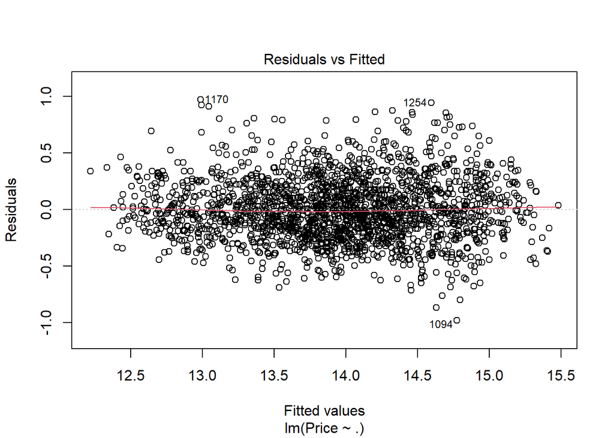

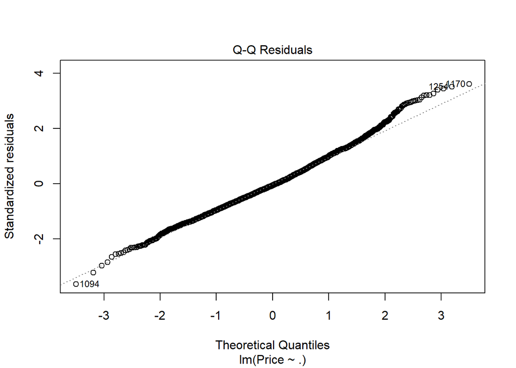

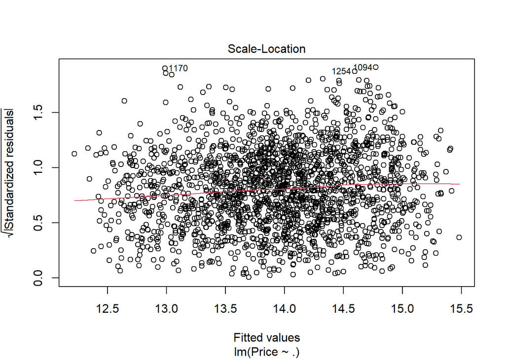

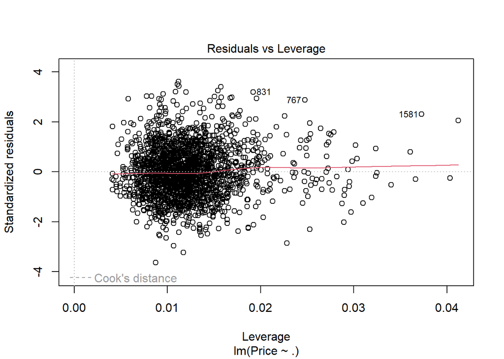

```r
mid_tier_ln <- mid_tier %>%
  mutate_at(vars(Price, Total_area_m2), log) %>%
  mutate(Age_years = log(Age_years + 1)) %>%
  mutate_at(vars(Price, Total_area_m2),
            ~ifelse(is.infinite(.), 0, .)) %>%
  dplyr::select(-c(NEIGHBORHOOD, Apartment, Usable_area_m2, POPULATION, DENSITY, CICLOWAYS,
                   GREEN_AREA, HOSPITALS, TERMINALS, PRIVATE_SCHOOLS, PUBLIC_SCHOOLS,
                   CULTURE_FACILITIES, SHOPPINGS, latitude, longitude, full_address))

mid_lm_ln <- lm(Price ~ .,
                data = mid_tier_ln)

## Plots

plot(mid_lm_ln)
```

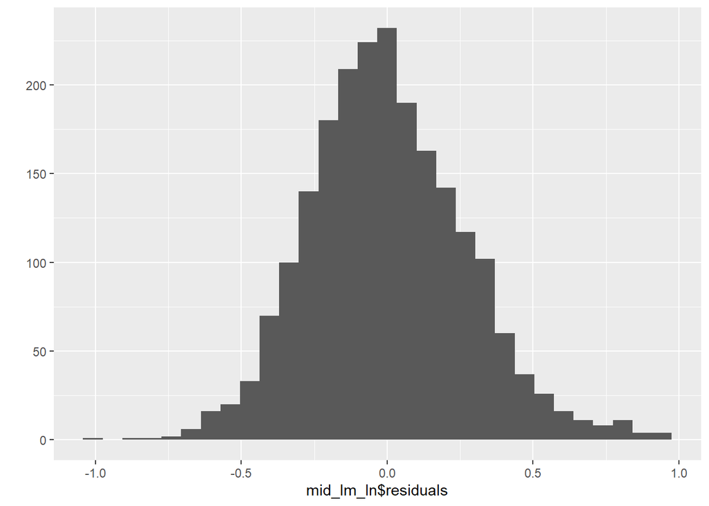

```r
qplot(mid_lm_ln$residuals)
```

```r
## Normality

jarque.bera.test(mid_lm_ln$residuals)
```

```
##
##  Jarque Bera Test
##
## data:  mid_lm_ln$residuals
## X-squared = 53.407, df = 2, p-value = 2.528e-12
```

```r
## Heteroskedasticity

white_test(mid_lm_ln)
```

```
## White's test results
##
## Null hypothesis: Homoskedasticity of the residuals
## Alternative hypothesis: Heteroskedasticity of the residuals
## Test Statistic: 20.25
## P-value: 4e-05
```

```r
## Spatial autocorrelation

mid_tier_sf <- mid_tier %>%
  filter(!is.na(latitude) & !is.na(longitude)) %>%
  st_as_sf(coords = c("longitude", "latitude"), crs = 4326)

coords <- st_coordinates(mid_tier_sf)
knn <- knearneigh(coords, k = 5)
nb <- knn2nb(knn)
listw <- nb2listw(nb, style = "W")

residuals_mid <- residuals(mid_lm_ln)

moran.test(residuals_mid, listw)
```

```
##
##  Moran I test under randomisation
##
## data:  residuals_mid
## weights: listw
##
## Moran I statistic standard deviate = 20.932, p-value < 2.2e-16
## alternative hypothesis: greater
## sample estimates:
## Moran I statistic       Expectation          Variance
##      0.2620094371     -0.0004705882      0.0001572409
```

```r
## Multicolinearity

car::vif(mid_lm_ln)
```

```
##      Off_plan Total_area_m2     Age_years    Party_room     Game_room
##      1.668930      4.889433      2.132510      1.729965      1.508946
##           Gym          Pool         Sauna           BBQ Gourmet_space
##      1.992696      1.607148      1.238171      1.239060      1.388425
##  Sports_court    Guardhouse       Cameras       Balcony    Playground
##      1.492644      1.422692      1.140004      1.157735      2.075916
##      PARKING1      PARKING2      BEDROOM1      BEDROOM2      BEDROOM3
##      2.414804      3.442429      3.743340      8.340433      6.000786
##      BEDROOM4     BATHROOM1     BATHROOM2     BATHROOM3     BATHROOM4
##      2.066250      3.313067      4.304665      4.496608      4.754887
```

```r
## Summary

summary(mid_lm_ln)
```

```
##
## Call:
## lm(formula = Price ~ ., data = mid_tier_ln)
##
## Residuals:
##      Min       1Q   Median       3Q      Max
## -0.97996 -0.17995 -0.01765  0.17024  0.96964
##
## Coefficients:
##                Estimate Std. Error t value Pr(>|t|)
## (Intercept)   11.003260   0.068487 160.662  < 2e-16 ***
## Off_plan      -0.050084   0.021180  -2.365 0.018138 *
## Total_area_m2  0.483098   0.017526  27.565  < 2e-16 ***
## Age_years     -0.093822   0.006951 -13.497  < 2e-16 ***
## Party_room     0.078171   0.015928   4.908 9.92e-07 ***
## Game_room     -0.037873   0.015597  -2.428 0.015259 *
## Gym            0.081206   0.016623   4.885 1.11e-06 ***
## Pool           0.081302   0.015215   5.343 1.01e-07 ***
## Sauna          0.066236   0.020087   3.297 0.000992 ***
## BBQ            0.008222   0.016325   0.504 0.614574
## Gourmet_space  0.031878   0.013919   2.290 0.022109 *
## Sports_court   0.010217   0.015233   0.671 0.502461
## Guardhouse     0.001119   0.014303   0.078 0.937660
## Cameras       -0.017582   0.016838  -1.044 0.296518
## Balcony       -0.028305   0.014011  -2.020 0.043497 *
## Playground     0.111068   0.016885   6.578 6.00e-11 ***
## PARKING1       0.126364   0.018634   6.781 1.54e-11 ***
## PARKING2       0.320611   0.024210  13.243  < 2e-16 ***
## BEDROOM1       0.035253   0.029910   1.179 0.238681
## BEDROOM2       0.057118   0.034018   1.679 0.093286 .
## BEDROOM3       0.090062   0.041084   2.192 0.028480 *
## BEDROOM4      -0.019746   0.056087  -0.352 0.724833
## BATHROOM1      0.184980   0.025163   7.351 2.80e-13 ***
## BATHROOM2      0.349085   0.028410  12.287  < 2e-16 ***
## BATHROOM3      0.434968   0.031527  13.797  < 2e-16 ***
## BATHROOM4      0.607943   0.034873  17.433  < 2e-16 ***
## ---
## Signif. codes:  0 '***' 0.001 '**' 0.01 '*' 0.05 '.' 0.1 ' ' 1
##
## Residual standard error: 0.27 on 2100 degrees of freedom
## Multiple R-squared:  0.8519, Adjusted R-squared:  0.8501
## F-statistic: 483.2 on 25 and 2100 DF,  p-value: < 2.2e-16
```

### 4.2.2. Addressing the spatial correlation and heteroscedasticity through Conley SEs

```r
mid_tier_conley <- mid_tier %>%
  filter(!is.na(latitude) & !is.na(longitude)) %>%
  mutate(Price = log(Price),
         Total_area_m2 = log(Total_area_m2),
         Age_years = log(Age_years + 1))

mid_conley <- conleyreg(Price ~ Total_area_m2 + Age_years +
                          Off_plan + Party_room + Game_room + Gym + Pool +
                          Sauna + BBQ + Gourmet_space + Sports_court + Guardhouse +
                          Cameras + Balcony + Playground +
                          PARKING1 + PARKING2 +
                          BEDROOM1 + BEDROOM2 + BEDROOM3 + BEDROOM4 +
                          BATHROOM1 + BATHROOM2 + BATHROOM3 + BATHROOM4,
                        data = mid_tier_conley,
                        lat = "latitude",
                        lon = "longitude",
                        dist_cutoff = 2)
```

```
## Checking spatial attributes
```

```
## Estimating model
```

```
## Estimating distance matrix and addressing spatial correlation
```

```r
mid_conley
```

```
##
## t test of coefficients:
##
##                 Estimate Std. Error t value  Pr(>|t|)
## (Intercept)   11.0032596  0.1110119 99.1178 < 2.2e-16 ***
## Total_area_m2  0.4830983  0.0276763 17.4553 < 2.2e-16 ***
## Age_years     -0.0938217  0.0112000 -8.3769 < 2.2e-16 ***
## Off_plan      -0.0500837  0.0293524 -1.7063   0.08810 .
## Party_room     0.0781707  0.0178713  4.3741 1.279e-05 ***
## Game_room     -0.0378731  0.0167694 -2.2585   0.02402 *
## Gym            0.0812057  0.0165717  4.9003 1.030e-06 ***
## Pool           0.0813016  0.0163060  4.9860 6.670e-07 ***
## Sauna          0.0662355  0.0331164  2.0001   0.04562 *
## BBQ            0.0082218  0.0176638  0.4655   0.64165
## Gourmet_space  0.0318777  0.0168471  1.8922   0.05860 .
## Sports_court   0.0102171  0.0174735  0.5847   0.55880
## Guardhouse     0.0011188  0.0160036  0.0699   0.94427
## Cameras       -0.0175820  0.0159710 -1.1009   0.27108
## Balcony       -0.0283047  0.0154708 -1.8296   0.06746 .
## Playground     0.1110677  0.0198995  5.5814 2.694e-08 ***
## PARKING1       0.1263641  0.0231253  5.4643 5.198e-08 ***
## PARKING2       0.3206109  0.0367176  8.7318 < 2.2e-16 ***
## BEDROOM1       0.0352528  0.0389601  0.9048   0.36565
## BEDROOM2       0.0571182  0.0437285  1.3062   0.19163
## BEDROOM3       0.0900621  0.0468416  1.9227   0.05465 .
## BEDROOM4      -0.0197457  0.0629398 -0.3137   0.75376
## BATHROOM1      0.1849800  0.0254444  7.2700 5.048e-13 ***
## BATHROOM2      0.3490850  0.0319715 10.9186 < 2.2e-16 ***
## BATHROOM3      0.4349680  0.0331520 13.1204 < 2.2e-16 ***
## BATHROOM4      0.6079432  0.0427250 14.2292 < 2.2e-16 ***
## ---
## Signif. codes:  0 '***' 0.001 '**' 0.01 '*' 0.05 '.' 0.1 ' ' 1
```

## 4.3. High tier

### 4.3.1. First Regression (First Stage of Rosen - Only Intrinsic Characteristics)

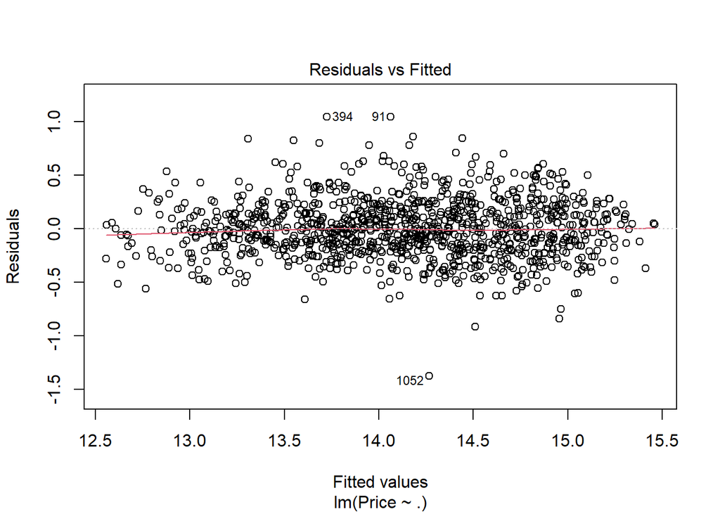

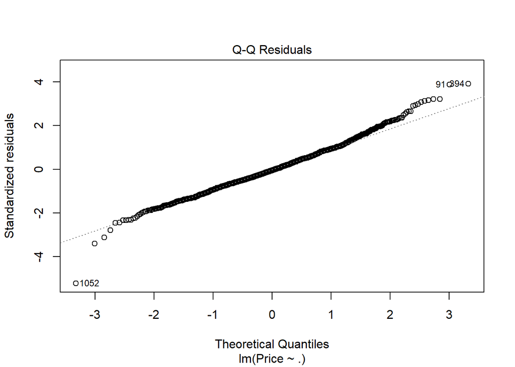

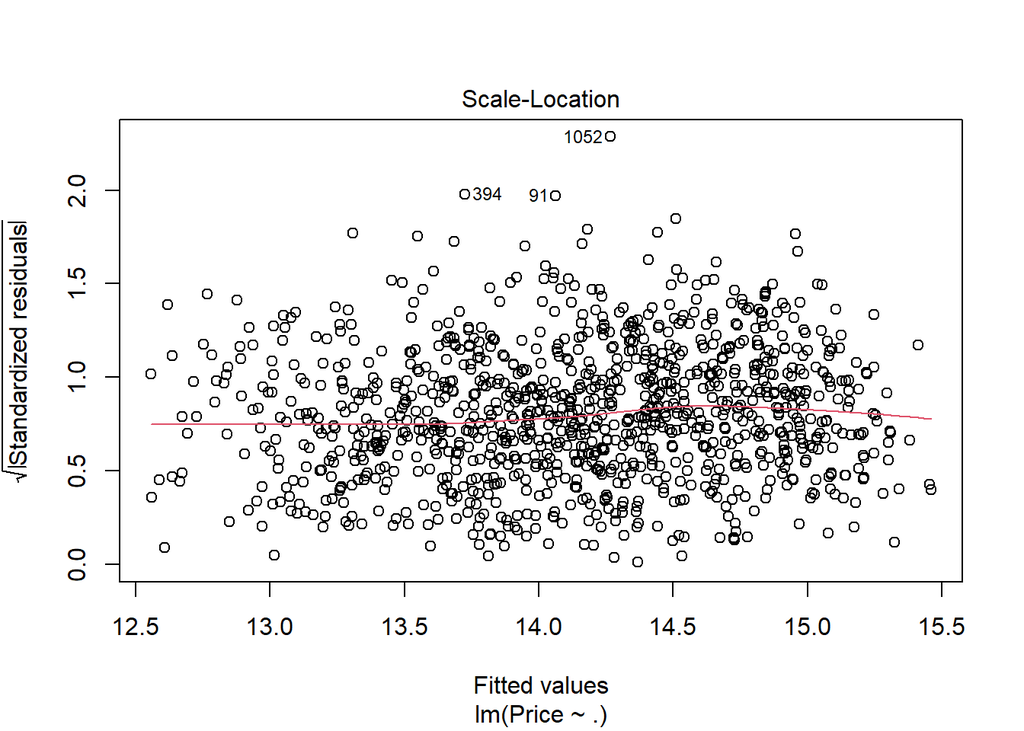

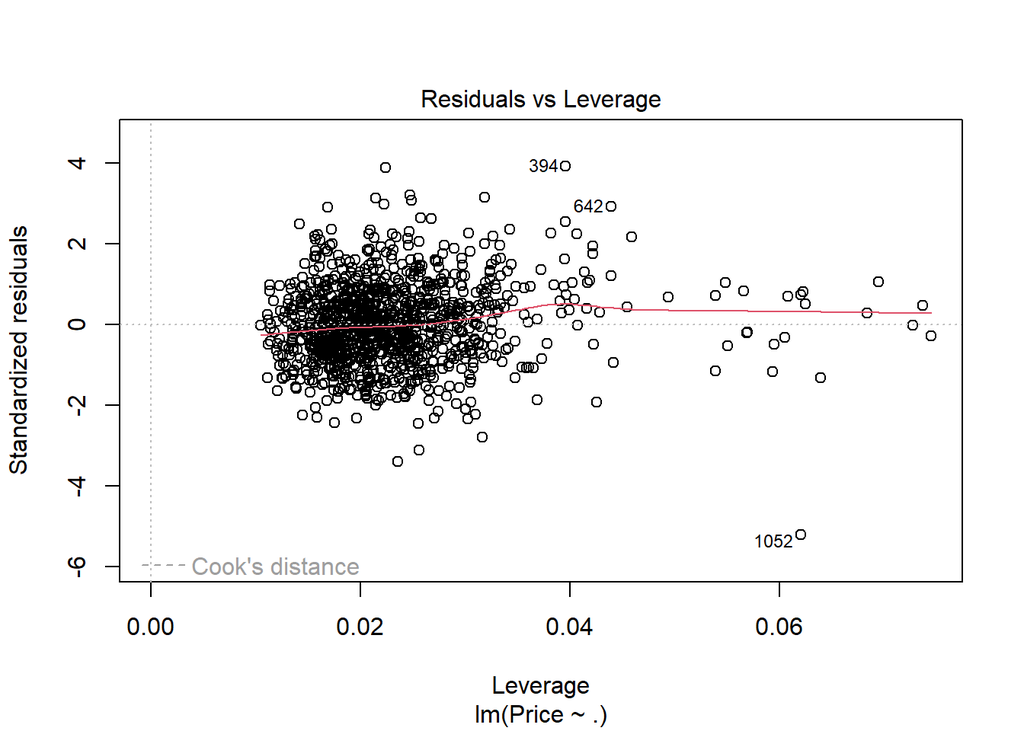

```r
high_tier_ln <- high_tier %>%
  mutate_at(vars(Price, Total_area_m2), log) %>%
  mutate(Age_years = log(Age_years + 1)) %>%
  mutate_at(vars(Price, Total_area_m2),
            ~ifelse(is.infinite(.), 0, .)) %>%
  dplyr::select(-c(NEIGHBORHOOD, Apartment, Usable_area_m2, POPULATION, DENSITY, CICLOWAYS,
                   GREEN_AREA, HOSPITALS, TERMINALS, PRIVATE_SCHOOLS, PUBLIC_SCHOOLS,
                   CULTURE_FACILITIES, SHOPPINGS, latitude, longitude, full_address))

high_lm_ln <- lm(Price ~ .,
                 data = high_tier_ln)

# Plots

plot(high_lm_ln)
```

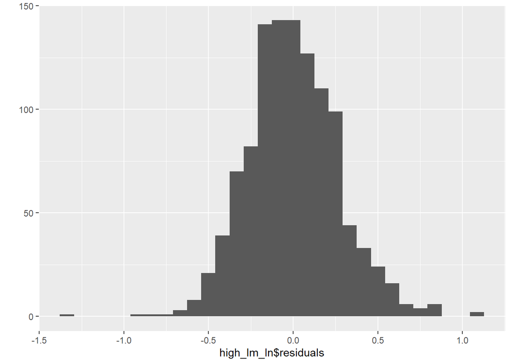

```r
qplot(high_lm_ln$residuals)
```

```r
## Normality

jarque.bera.test(high_lm_ln$residuals)
```

```
##
##  Jarque Bera Test
##
## data:  high_lm_ln$residuals
## X-squared = 58.12, df = 2, p-value = 2.396e-13
```

```r
## Heteroskedasticity

white_test(high_lm_ln) # this time, no heteroskedasticity
```

```
## White's test results
##
## Null hypothesis: Homoskedasticity of the residuals
## Alternative hypothesis: Heteroskedasticity of the residuals
## Test Statistic: 5.3
## P-value: 0.070549
```

```r
## Spatial autocorrelation

high_tier_sf <- high_tier %>%
  filter(!is.na(latitude) & !is.na(longitude)) %>%
  st_as_sf(coords = c("longitude", "latitude"), crs = 4326)

coords <- st_coordinates(high_tier_sf)
knn <- knearneigh(coords, k = 5)
nb <- knn2nb(knn)
listw <- nb2listw(nb, style = "W")

residuals_high <- residuals(high_lm_ln)

moran.test(residuals_high, listw)
```

```
##
##  Moran I test under randomisation
##
## data:  residuals_high
## weights: listw
##
## Moran I statistic standard deviate = 14.617, p-value < 2.2e-16
## alternative hypothesis: greater
## sample estimates:
## Moran I statistic       Expectation          Variance
##      0.2523499268     -0.0008896797      0.0003001475
```

```r
## Multicolinearity

car::vif(high_lm_ln)
```

```
##      Off_plan Total_area_m2     Age_years    Party_room     Game_room
##      1.645191      4.609331      2.640286      1.320968      1.354494
##           Gym          Pool         Sauna           BBQ Gourmet_space
##      1.853533      1.427337      1.219001      1.367555      1.451718
##  Sports_court    Guardhouse       Cameras       Balcony    Playground
##      1.193529      1.287083      1.128482      1.287748      1.733062
##      PARKING1      PARKING2      BEDROOM1      BEDROOM2      BEDROOM3
##      2.622972      4.263027      3.998348      7.715225      5.627792
##      BEDROOM4     BATHROOM1     BATHROOM2     BATHROOM3     BATHROOM4
##      1.814568      3.245527      4.122563      4.227092      5.851976
```

```r
## Summary

summary(high_lm_ln)
```

```
##
## Call:
## lm(formula = Price ~ ., data = high_tier_ln)
##
## Residuals:
##      Min       1Q   Median       3Q      Max
## -1.37765 -0.17479 -0.01312  0.16320  1.04574
##
## Coefficients:
##                Estimate Std. Error t value Pr(>|t|)
## (Intercept)   11.025790   0.107091 102.958  < 2e-16 ***
## Off_plan      -0.058881   0.030132  -1.954  0.05094 .
## Total_area_m2  0.552124   0.025690  21.492  < 2e-16 ***
## Age_years     -0.129262   0.009889 -13.071  < 2e-16 ***
## Party_room     0.008134   0.021505   0.378  0.70532
## Game_room     -0.006151   0.020363  -0.302  0.76268
## Gym            0.040967   0.022932   1.786  0.07430 .
## Pool           0.130310   0.019869   6.559 8.34e-11 ***
## Sauna          0.028763   0.027074   1.062  0.28828
## BBQ           -0.035105   0.022709  -1.546  0.12242
## Gourmet_space  0.060369   0.019806   3.048  0.00236 **
## Sports_court  -0.022651   0.019086  -1.187  0.23557
## Guardhouse     0.034507   0.018568   1.858  0.06338 .
## Cameras       -0.036589   0.021491  -1.703  0.08893 .
## Balcony       -0.001038   0.021360  -0.049  0.96125
## Playground     0.009481   0.021652   0.438  0.66157
## PARKING1       0.186683   0.026840   6.955 6.03e-12 ***
## PARKING2       0.357022   0.036473   9.789  < 2e-16 ***
## BEDROOM1       0.050471   0.041513   1.216  0.22433
## BEDROOM2       0.040657   0.045308   0.897  0.36973
## BEDROOM3       0.047493   0.054859   0.866  0.38682
## BEDROOM4      -0.030867   0.080806  -0.382  0.70254
## BATHROOM1      0.114189   0.035232   3.241  0.00123 **
## BATHROOM2      0.202551   0.039428   5.137 3.30e-07 ***
## BATHROOM3      0.295681   0.043407   6.812 1.58e-11 ***
## BATHROOM4      0.403383   0.046592   8.658  < 2e-16 ***
## ---
## Signif. codes:  0 '***' 0.001 '**' 0.01 '*' 0.05 '.' 0.1 ' ' 1
##
## Residual standard error: 0.2723 on 1099 degrees of freedom
## Multiple R-squared:  0.8429, Adjusted R-squared:  0.8393
## F-statistic: 235.8 on 25 and 1099 DF,  p-value: < 2.2e-16
```

### 4.3.2. Addressing the spatial correlation and heteroscedasticity through Conley SEs

```r
high_tier_conley <- high_tier %>%
  filter(!is.na(latitude) & !is.na(longitude)) %>%
  mutate(Price = log(Price),
         Total_area_m2 = log(Total_area_m2),
         Age_years = log(Age_years + 1))

high_conley <- conleyreg(Price ~ Total_area_m2 + Age_years +
                           Off_plan + Party_room + Game_room + Gym + Pool +
                           Sauna + BBQ + Gourmet_space + Sports_court + Guardhouse +
                           Cameras + Balcony + Playground +
                           PARKING1 + PARKING2 +
                           BEDROOM1 + BEDROOM2 + BEDROOM3 + BEDROOM4 +
                           BATHROOM1 + BATHROOM2 + BATHROOM3 + BATHROOM4,
                         data = high_tier_conley,
                         lat = "latitude",
                         lon = "longitude",
                         dist_cutoff = 2)
```

```
## Checking spatial attributes
```

```
## Estimating model
```

```
## Estimating distance matrix and addressing spatial correlation
```

```r
high_conley
```

```
##
## t test of coefficients:
##
##                 Estimate Std. Error  t value  Pr(>|t|)
## (Intercept)   11.0257900  0.1557208  70.8049 < 2.2e-16 ***
## Total_area_m2  0.5521243  0.0517281  10.6736 < 2.2e-16 ***
## Age_years     -0.1292622  0.0129122 -10.0109 < 2.2e-16 ***
## Off_plan      -0.0588814  0.0426167  -1.3817 0.1673594
## Party_room     0.0081343  0.0242126   0.3360 0.7369707
## Game_room     -0.0061506  0.0299649  -0.2053 0.8374080
## Gym            0.0409667  0.0199969   2.0487 0.0407329 *
## Pool           0.1303103  0.0295370   4.4118 1.126e-05 ***
## Sauna          0.0287633  0.0327944   0.8771 0.3806346
## BBQ           -0.0351053  0.0257691  -1.3623 0.1733819
## Gourmet_space  0.0603693  0.0157458   3.8340 0.0001332 ***
## Sports_court  -0.0226505  0.0152294  -1.4873 0.1372237
## Guardhouse     0.0345068  0.0165539   2.0845 0.0373446 *
## Cameras       -0.0365887  0.0168291  -2.1741 0.0299076 *
## Balcony       -0.0010380  0.0274558  -0.0378 0.9698491
## Playground     0.0094809  0.0336855   0.2815 0.7784170
## PARKING1       0.1866833  0.0329464   5.6663 1.863e-08 ***
## PARKING2       0.3570220  0.0515330   6.9280 7.253e-12 ***
## BEDROOM1       0.0504712  0.0790424   0.6385 0.5232598
## BEDROOM2       0.0406572  0.1109085   0.3666 0.7140007
## BEDROOM3       0.0474935  0.1146367   0.4143 0.6787386
## BEDROOM4      -0.0308671  0.1538678  -0.2006 0.8410424
## BATHROOM1      0.1141888  0.0359871   3.1730 0.0015503 **
## BATHROOM2      0.2025509  0.0399704   5.0675 4.725e-07 ***
## BATHROOM3      0.2956814  0.0476816   6.2012 7.920e-10 ***
## BATHROOM4      0.4033834  0.0521549   7.7343 2.341e-14 ***
## ---
## Signif. codes:  0 '***' 0.001 '**' 0.01 '*' 0.05 '.' 0.1 ' ' 1
```

# 5. Rosen’s Second Stage

## 5.1. Low tier (Second Stage of Rosen - Both Intrinsic and Extrinsic Characteristics)

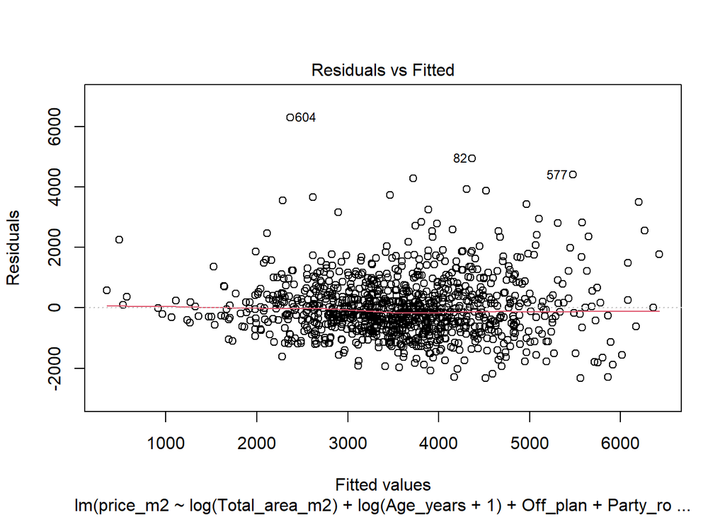

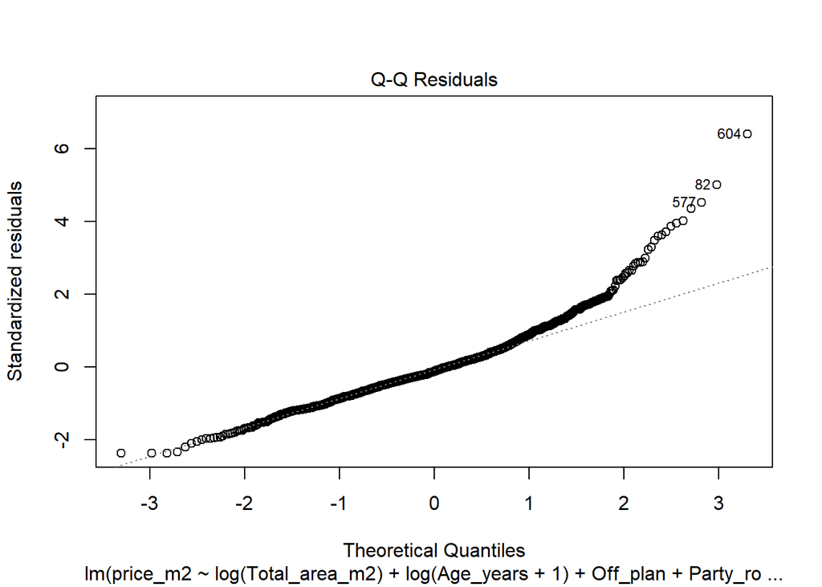

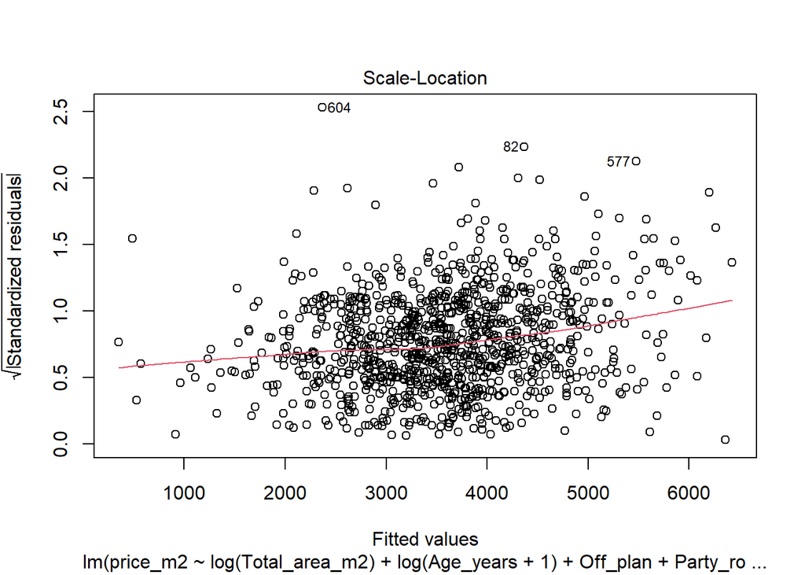

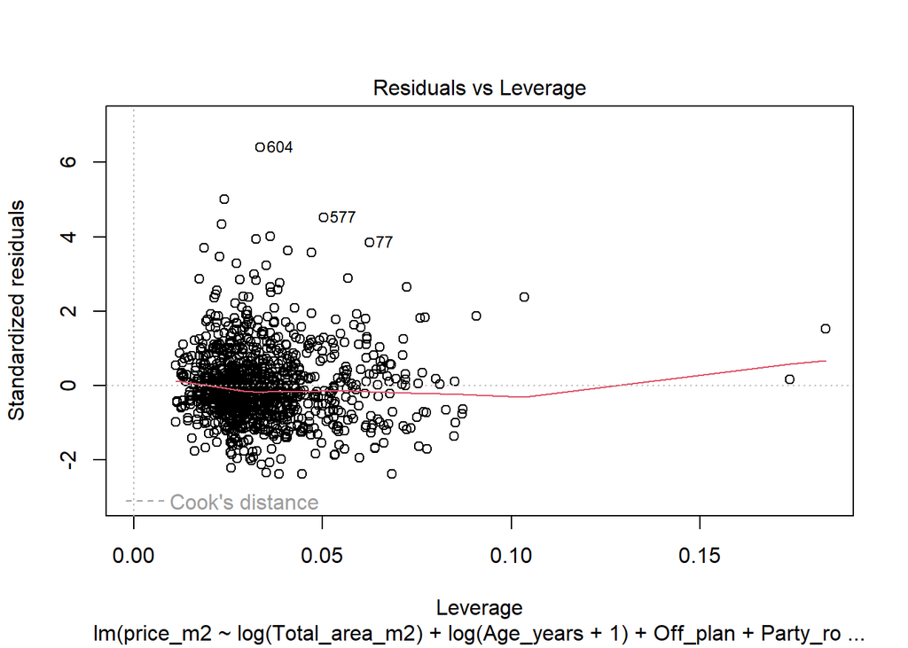

```r
# Coefficient from first stage
beta_area_low <- coef(low_lm_ln)["Total_area_m2"]

# Dependent variable for second stage
low_tier$price_m2 <- beta_area_low*(low_tier$Price/low_tier$Total_area_m2)

# Second stage regression
low_supply <- lm(price_m2 ~
                   # Intrinsic (z)
                   log(Total_area_m2) + log(Age_years + 1) +
                   Off_plan + Party_room + Game_room + Gym + Pool +
                   Sauna + BBQ + Gourmet_space + Sports_court + Guardhouse +
                   Cameras + Balcony + Playground +
                   PARKING1 + PARKING2 +
                   BEDROOM1 + BEDROOM2 + BEDROOM3 + BEDROOM4 +
                   BATHROOM1 + BATHROOM2 + BATHROOM3 + BATHROOM4 +
                   # Y2 - Supply shifters (continuous = log)
                   log(DENSITY) + log(POPULATION) +
                   # W - Location variables
                   GREEN_AREA + CICLOWAYS +
                   HOSPITALS + TERMINALS + PRIVATE_SCHOOLS +
                   PUBLIC_SCHOOLS + CULTURE_FACILITIES + SHOPPINGS,
                 data = low_tier)

## Plots

plot(low_supply)
```

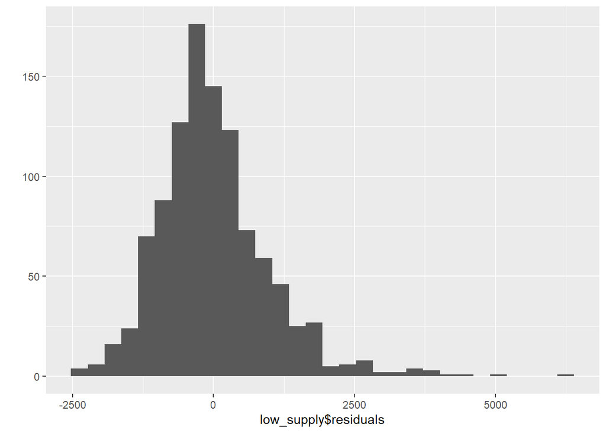

```r
qplot(low_supply$residuals)
```

```r
## Normality

jarque.bera.test(low_supply$residuals)
```

```
##
##  Jarque Bera Test
##
## data:  low_supply$residuals
## X-squared = 811.78, df = 2, p-value < 2.2e-16
```

```r
## Heteroskedasticiy

white_test(low_supply)
```

```
## White's test results
##
## Null hypothesis: Homoskedasticity of the residuals
## Alternative hypothesis: Heteroskedasticity of the residuals
## Test Statistic: 29.25
## P-value: 0
```

```r
## Multicolinearity

car::vif(low_supply)
```

```
## log(Total_area_m2) log(Age_years + 1)           Off_plan         Party_room
##           3.546864           1.868010           1.532281           2.161037
##          Game_room                Gym               Pool              Sauna
##           1.811081           1.921102           1.696053           1.260927
##                BBQ      Gourmet_space       Sports_court         Guardhouse
##           1.270742           1.400733           1.856602           1.594104
##            Cameras            Balcony         Playground           PARKING1
##           1.202118           1.190561           2.449832           2.451255
##           PARKING2           BEDROOM1           BEDROOM2           BEDROOM3
##           3.333586           7.208764          14.043443          10.134322
##           BEDROOM4          BATHROOM1          BATHROOM2          BATHROOM3
##           3.038322           2.493480           3.761955           3.422391
##          BATHROOM4       log(DENSITY)    log(POPULATION)         GREEN_AREA
##           3.755534           2.155545           2.661583           2.539394
##          CICLOWAYS          HOSPITALS          TERMINALS    PRIVATE_SCHOOLS
##           1.274814           2.542742           5.103851           1.190590
##     PUBLIC_SCHOOLS CULTURE_FACILITIES          SHOPPINGS
##           1.717053           3.143655           1.506423
```

```r
## Summary

summary(low_supply)
```

```
##
## Call:
## lm(formula = price_m2 ~ log(Total_area_m2) + log(Age_years +
##     1) + Off_plan + Party_room + Game_room + Gym + Pool + Sauna +
##     BBQ + Gourmet_space + Sports_court + Guardhouse + Cameras +
##     Balcony + Playground + PARKING1 + PARKING2 + BEDROOM1 + BEDROOM2 +
##     BEDROOM3 + BEDROOM4 + BATHROOM1 + BATHROOM2 + BATHROOM3 +
##     BATHROOM4 + log(DENSITY) + log(POPULATION) + GREEN_AREA +
##     CICLOWAYS + HOSPITALS + TERMINALS + PRIVATE_SCHOOLS + PUBLIC_SCHOOLS +
##     CULTURE_FACILITIES + SHOPPINGS, data = low_tier)
##
## Residuals:
##     Min      1Q  Median      3Q     Max
## -2332.9  -605.9  -127.3   451.2  6291.6
##
## Coefficients:
##                    Estimate Std. Error t value Pr(>|t|)
## (Intercept)        10152.34     730.95  13.889  < 2e-16 ***
## log(Total_area_m2) -1117.79      87.56 -12.765  < 2e-16 ***
## log(Age_years + 1)  -357.83      37.69  -9.494  < 2e-16 ***
## Off_plan            -258.49     134.40  -1.923  0.05472 .
## Party_room           426.22      92.28   4.619 4.36e-06 ***
## Game_room           -299.51     107.44  -2.788  0.00541 **
## Gym                  439.83      93.49   4.705 2.90e-06 ***
## Pool                 412.21      92.11   4.475 8.50e-06 ***
## Sauna                214.93     136.18   1.578  0.11483
## BBQ                   48.79      81.70   0.597  0.55056
## Gourmet_space        211.48      73.77   2.867  0.00423 **
## Sports_court        -132.01      90.01  -1.467  0.14280
## Guardhouse          -126.38      84.42  -1.497  0.13470
## Cameras             -120.09      93.90  -1.279  0.20119
## Balcony              -78.01      70.36  -1.109  0.26781
## Playground           324.11      99.19   3.267  0.00112 **
## PARKING1             277.59      98.81   2.809  0.00506 **
## PARKING2             668.20     120.52   5.544 3.77e-08 ***
## BEDROOM1            -228.77     224.39  -1.020  0.30819
## BEDROOM2              68.04     236.90   0.287  0.77402
## BEDROOM3             228.44     257.87   0.886  0.37589
## BEDROOM4             241.82     308.12   0.785  0.43274
## BATHROOM1            139.94     115.58   1.211  0.22628
## BATHROOM2            397.37     132.98   2.988  0.00287 **
## BATHROOM3            961.75     148.30   6.485 1.39e-10 ***
## BATHROOM4           1436.52     174.33   8.240 5.31e-16 ***
## log(DENSITY)         -44.88     114.19  -0.393  0.69435
## log(POPULATION)     -175.21      69.41  -2.524  0.01175 *
## GREEN_AREA          -145.66      98.71  -1.476  0.14033
## CICLOWAYS            283.37     160.51   1.765  0.07779 .
## HOSPITALS            193.58      99.52   1.945  0.05203 .
## TERMINALS            -48.83     148.90  -0.328  0.74305
## PRIVATE_SCHOOLS      404.69     220.73   1.833  0.06704 .
## PUBLIC_SCHOOLS      -127.62     231.63  -0.551  0.58178
## CULTURE_FACILITIES  -222.65     132.32  -1.683  0.09276 .
## SHOPPINGS           -210.59     147.92  -1.424  0.15485
## ---
## Signif. codes:  0 '***' 0.001 '**' 0.01 '*' 0.05 '.' 0.1 ' ' 1
##
## Residual standard error: 999.3 on 1007 degrees of freedom
## Multiple R-squared:  0.4738, Adjusted R-squared:  0.4555
## F-statistic:  25.9 on 35 and 1007 DF,  p-value: < 2.2e-16
```

```r
## Conley SEs for spatial autocorrelation and heteroskedasticity

beta_area_low <- coef(low_conley)["Total_area_m2"]

low_tier_conley$price_m2 <- beta_area_low*(low_tier_conley$Price/low_tier_conley$Total_area_m2)

low_supply_conley <- conleyreg(price_m2 ~
                                 Total_area_m2 + Age_years +
                                 Off_plan + Party_room + Game_room + Gym + Pool +
                                 Sauna + BBQ + Gourmet_space + Sports_court + Guardhouse +
                                 Cameras + Balcony + Playground +
                                 PARKING1 + PARKING2 +
                                 BEDROOM1 + BEDROOM2 + BEDROOM3 + BEDROOM4 +
                                 BATHROOM1 + BATHROOM2 + BATHROOM3 + BATHROOM4 +
                                 # Y2 - Supply shifters
                                 log(POPULATION) + log(DENSITY) +
                                 # W - Location variables
                                 CICLOWAYS + GREEN_AREA +
                                 HOSPITALS + TERMINALS + PRIVATE_SCHOOLS +
                                 PUBLIC_SCHOOLS + CULTURE_FACILITIES + SHOPPINGS,
                               data = low_tier_conley,
                               lat = "latitude",
                               lon = "longitude",
                               dist_cutoff = 2)
```

```
## Checking spatial attributes
## Estimating model
## Estimating distance matrix and addressing spatial correlation
```

```r
low_supply_conley
```

```
##
## t test of coefficients:
##
##                       Estimate  Std. Error  t value  Pr(>|t|)
## (Intercept)         3.08361423  0.06400466  48.1780 < 2.2e-16 ***
## Total_area_m2      -0.25671895  0.00789619 -32.5117 < 2.2e-16 ***
## Age_years          -0.01181405  0.00157372  -7.5071 1.329e-13 ***
## Off_plan            0.00218230  0.00715010   0.3052 0.7602677
## Party_room          0.01894934  0.00442472   4.2826 2.024e-05 ***
## Game_room          -0.00317700  0.00421955  -0.7529 0.4516719
## Gym                 0.01314795  0.00375989   3.4969 0.0004912 ***
## Pool                0.01989104  0.00455731   4.3646 1.405e-05 ***
## Sauna               0.00625079  0.00574725   1.0876 0.2770255
## BBQ                 0.00064322  0.00339112   0.1897 0.8495994
## Gourmet_space       0.01332950  0.00413595   3.2228 0.0013100 **
## Sports_court       -0.00891812  0.00365047  -2.4430 0.0147366 *
## Guardhouse         -0.00355857  0.00394283  -0.9025 0.3669852
## Cameras            -0.00398429  0.00403808  -0.9867 0.3240367
## Balcony            -0.00355361  0.00312650  -1.1366 0.2559717
## Playground          0.00541518  0.00472426   1.1463 0.2519639
## PARKING1           -0.00218216  0.00475640  -0.4588 0.6464886
## PARKING2            0.01934149  0.00644522   3.0009 0.0027581 **
## BEDROOM1           -0.07705595  0.02625902  -2.9345 0.0034171 **
## BEDROOM2           -0.06852924  0.02660519  -2.5758 0.0101429 *
## BEDROOM3           -0.05701556  0.02698316  -2.1130 0.0348459 *
## BEDROOM4           -0.04115716  0.02690218  -1.5299 0.1263601
## BATHROOM1          -0.01035178  0.00537828  -1.9247 0.0545438 .
## BATHROOM2           0.00169036  0.00600327   0.2816 0.7783281
## BATHROOM3           0.02151464  0.00780617   2.7561 0.0059550 **
## BATHROOM4           0.05192394  0.00728124   7.1312 1.898e-12 ***
## log(POPULATION)    -0.00651416  0.00470458  -1.3846 0.1664685
## log(DENSITY)       -0.00220153  0.00693038  -0.3177 0.7508058
## CICLOWAYS           0.01094665  0.00944641   1.1588 0.2468061
## GREEN_AREA         -0.00493266  0.00701167  -0.7035 0.4819116
## HOSPITALS           0.00824656  0.00816524   1.0100 0.3127576
## TERMINALS           0.00235201  0.00980135   0.2400 0.8104041
## PRIVATE_SCHOOLS     0.01602516  0.01272140   1.2597 0.2080689
## PUBLIC_SCHOOLS     -0.00558046  0.01156807  -0.4824 0.6296253
## CULTURE_FACILITIES -0.00938170  0.00821957  -1.1414 0.2539806
## SHOPPINGS          -0.00774500  0.00769089  -1.0070 0.3141594
## ---
## Signif. codes:  0 '***' 0.001 '**' 0.01 '*' 0.05 '.' 0.1 ' ' 1
```